# R Notebook

# Libraries

```r
library(janitor)
```

# Data

## Data cleaning

```r
telco_clean <- telco_churn %>%
  filter(!is.na(total_charges)) %>%
  select(-customer_id) %>%
  mutate(across(where(is_character), as_factor)) %>%
  mutate(senior_citizen = as_factor(if_else(senior_citizen == 1, "Yes", "No"))) %>%
  mutate(churn = churn == "Yes")
```

# 1) Let’s perform logistic regression using the churn column as the binary dependent variable. Create three separate single predictor logistic regression models choosing from amongst the promising predictor columns found in the analysis above (look at the pairs plots). Try to have at least one continuous predictor, and at least one categorical predictor. Check that the coefficient of the single predictor in each model is statistically significant.

| gender | senior_citizen | partner | dependents | tenure | phone_service | internet_service | contract | monthly_charges | total_charges | churn |
| --- | --- | --- | --- | --- | --- | --- | --- | --- | --- | --- |
| Female | No | Yes | No | 1 | No | DSL | Month-to-month | 29.85 | 29.85 | No |
| Male | No | No | No | 34 | Yes | DSL | One year | 56.95 | 1889.50 | No |
| Male | No | No | No | 2 | Yes | DSL | Month-to-month | 53.85 | 108.15 | Yes |
| Male | No | No | No | 45 | No | DSL | One year | 42.30 | 1840.75 | No |
| Female | No | No | No | 2 | Yes | Fiber optic | Month-to-month | 70.70 | 151.65 | Yes |
| Female | No | No | No | 8 | Yes | Fiber optic | Month-to-month | 99.65 | 820.50 | Yes |

## Let’s try monthly_charges, tenure, partner

```r
#model with partner
mod_partner <- glm(churn ~ partner,
                   data = telco_clean,
                   family = binomial(link = "logit"))

mod_partner_pred <- telco_clean %>%
  add_predictions(model = mod_partner, type = "response") %>%
  mutate(pred_churn = pred >= 0.30)

summary(mod_partner)
```

```
Call:
glm(formula = churn ~ partner, family = binomial(link = "logit"),
    data = telco_clean)

Deviance Residuals:
    Min       1Q   Median       3Q      Max
-0.8946  -0.8946  -0.6627   1.4896   1.8020

Coefficients:
            Estimate Std. Error z value Pr(>|z|)
(Intercept) -1.40407    0.04315  -32.54   <2e-16 ***
partnerNo    0.69481    0.05572   12.47   <2e-16 ***
---
Signif. codes:  0 ‘***’ 0.001 ‘**’ 0.01 ‘*’ 0.05 ‘.’ 0.1 ‘ ’ 1

(Dispersion parameter for binomial family taken to be 1)

    Null deviance: 8143.4  on 7031  degrees of freedom
Residual deviance: 7983.3  on 7030  degrees of freedom
AIC: 7987.3

Number of Fisher Scoring iterations: 4
```

```r
#model with tenure
mod_tenure <- glm(churn ~ tenure,
                   data = telco_clean,
                   family = binomial("logit"))

mod_tenure_pred <- telco_clean %>%
  add_predictions(model = mod_tenure, type = "response") %>%
  mutate(pred_churn = pred >= 0.30)

summary(mod_tenure)
```

```
Call:
glm(formula = churn ~ tenure, family = binomial("logit"), data = telco_clean)

Deviance Residuals:
    Min       1Q   Median       3Q      Max
-1.1767  -0.8401  -0.4788   1.1781   2.3800

Coefficients:
             Estimate Std. Error z value Pr(>|z|)
(Intercept)  0.037299   0.042319   0.881    0.378
tenure      -0.039010   0.001409 -27.691   <2e-16 ***
---
Signif. codes:  0 ‘***’ 0.001 ‘**’ 0.01 ‘*’ 0.05 ‘.’ 0.1 ‘ ’ 1

(Dispersion parameter for binomial family taken to be 1)

    Null deviance: 8143.4  on 7031  degrees of freedom
Residual deviance: 7176.3  on 7030  degrees of freedom
AIC: 7180.3

Number of Fisher Scoring iterations: 4
```

```r
#model with monthly_charges
mod_monthly_charges <- glm(churn ~ monthly_charges,
                   data = telco_clean,
                   family = binomial("logit"))

mod_monthly_charges_pred <- telco_clean %>%
  add_predictions(model = mod_monthly_charges, type = "response") %>%
  mutate(pred_churn = pred >= 0.30)

summary(mod_monthly_charges)
```

```
Call:
glm(formula = churn ~ monthly_charges, family = binomial("logit"),
    data = telco_clean)

Deviance Residuals:
    Min       1Q   Median       3Q      Max
-1.0785  -0.8501  -0.6537   1.3728   1.9643

Coefficients:
                  Estimate Std. Error z value Pr(>|z|)
(Intercept)     -2.0619850  0.0742186  -27.78   <2e-16 ***
monthly_charges  0.0153680  0.0009672   15.89   <2e-16 ***
---
Signif. codes:  0 ‘***’ 0.001 ‘**’ 0.01 ‘*’ 0.05 ‘.’ 0.1 ‘ ’ 1

(Dispersion parameter for binomial family taken to be 1)

    Null deviance: 8143.4  on 7031  degrees of freedom
Residual deviance: 7873.3  on 7030  degrees of freedom
AIC: 7877.3

Number of Fisher Scoring iterations: 4
```

# 2) Plot ROC curves for each classifier (it would be nice to put these on the same axes). Obtain AUC values for each of your classifiers and say which of them is likely to be the best classifier.

[figure not shown]

```r
auc(roc_obj_monthly_charges)
```

```
Area under the curve: 0.6203
```

```r
auc(roc_obj_partner)
```

```
Area under the curve: 0.5848
```

```r
auc(roc_obj_tenure)
```

```
Area under the curve: 0.7414
```

The model with tenure as a predictor has the best (highest) AUC value, so this is likely the best classifier.

```r
mod_tenure_pred %>%
  tabyl(churn, pred_churn) %>%
  adorn_title()
```

```
       pred_churn
 churn      FALSE TRUE
 FALSE       3438 1725
  TRUE        574 1295
```

Wow, lots of false positives!

# 3) Take the model generating the best classifier (highest AUC value) from amongst your three and interpret the fitted coefficient of the particular predictor in that model in a meaningful way. Think in terms of odds ratio, i.e. how does changing the predictor value affect the odds that a customer will churn?

We can see from the model and from the plot that tenure has a negative relationship with churn, meaning that as a customer’s tenure increases, they are less likely to churn.

```r
summary(mod_tenure)
```

```
Call:
glm(formula = churn ~ tenure, family = binomial("logit"), data = telco_clean)

Deviance Residuals:
    Min       1Q   Median       3Q      Max
-1.1767  -0.8401  -0.4788   1.1781   2.3800

Coefficients:
             Estimate Std. Error z value Pr(>|z|)
(Intercept)  0.037299   0.042319   0.881    0.378
tenure      -0.039010   0.001409 -27.691   <2e-16 ***
---
Signif. codes:  0 ‘***’ 0.001 ‘**’ 0.01 ‘*’ 0.05 ‘.’ 0.1 ‘ ’ 1

(Dispersion parameter for binomial family taken to be 1)

    Null deviance: 8143.4  on 7031  degrees of freedom
Residual deviance: 7176.3  on 7030  degrees of freedom
AIC: 7180.3

Number of Fisher Scoring iterations: 4
```

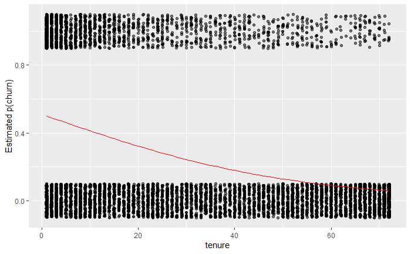

```r
ggplot(telco_clean) +
  geom_jitter(aes(x = tenure,
                  y = as.numeric(churn)),
              alpha = 0.5, height = 0.1, width = 0.1) +
  geom_line(data = mod_tenure_pred,
            aes(x = tenure,
                y = pred), col = "red")+
  labs(y = "Estimated p(churn)")
```

When we compute the odds factor for a 12 month increase in tenure, we can see that this decreases the odds of churn by a factor of 0.63.

```r
#so the coefficient for tenure was -0.039 and we're interested in a change of 12 months in tenure
odds_change(-0.039010, 12)
```

```
[1] 0.6261784
```